# U.S. Abortions

Alexis Valeriano and Iain Carlos

1/29/2020

Abortion Data in the United States

Hypothesis: We posit that the number of clinics in a particular state will have a positive correlation with the abortion rate of that state. Additionally, we posit that the percentage of uninsured women in a particular state will have a negative correlation with the abortion rate of a particular state.

Relevance: Abortion is a fraught topic in American politics. Many Americans deem the right to abort as good, necessary, and in need of protection. On the other hand, many Americans deem the right to abort to be morally reprehensible and hope to see it abolished. For both camps, this data is important because it can help explain what circumstances are correlated with higher and lower abortion rates.

Analysis: This data can tell us two main things - how many abortions are taking place, who is getting abortions, and what circumstances are correlated with higher and lower abortion rates.

Limitations: This data is only representative of the year 2017, and thus it cannot tell us how abortion data has changed over time in the United States. If we were to do this project again, we would try to find a longitudinal data set.

Conclusion: Although the positive correlation between the number of clinics and the abortion rate is stronger than the negative correlation between the percentage of uninsured women and the abortion rate, both of our hypotheses proved correct. In the future, should we find a longitudinal data set, we would want to determine how individual states’ abortion rates have changed over time, with particular attention to whether that state’s changing number of clinics affects that state’s abortion rate.

```r
us_states=map_data("state")

AbortionDataS$region=tolower(AbortionDataS$State)

us_state_abort2=left_join(subset(us_states, region %nin% "district of columbia"), AbortionDataS)
state <- data.table(region= "Connecticut","Maine","Massachusetts", "New Hampshire","Rhode Island", "Vermont", "New Jersey", "New York","Pennsylvania","Indiana","Illinois","Michigan","Ohio","Wisconsin", "Iowa","Kansas","Minnesota","Missouri","Nebraska", "North Dakota","South Dakota", "Delaware", "Florida", "Georgia", "Maryland","North Carolina","South Carolina","Virginia", "West Virginia", "Alabama","Kentucky", "Mississippi", "Tennessee","Arkansas","Louisiana","Oklahoma","Texas","Arizona","Colorado","Idaho","New Mexico","Montana", "Utah","Nevada","Wyoming","Alaska","California", "Hawaii","Oregon","Washington")

region7 <- data.table(region9="Northeast", "Northeast", "Northeast", "Northeast", "Northeast", "Northeast", "Northeast", "Northeast", "Northeast", "Midwest", "Midwest", "Midwest", "Midwest", "Midwest", "Midwest", "Midwest", "Midwest", "Midwest", "Midwest", "Midwest", "Midwest", "South", "South", "South", "South", "South", "South", "South", "South", "South", "South", "South", "South", "South", "South", "South", "South", "West", "West", "West", "West", "West", "West", "West", "West", "West", "West", "West", "West", "West")
```

```r
final7 = list(region7, state)
region8 <- data.table(rbindlist(final7))
region9 <- as.data.frame(t(region8))
rownames(region9) <- c()
region9$region<- tolower(region9$V2)
us_state_abort3 <- left_join(us_state_abort2, region9)
region9$State<- region9$V2
us_state_abort4 <- left_join(AbortionDataS, region9)
```

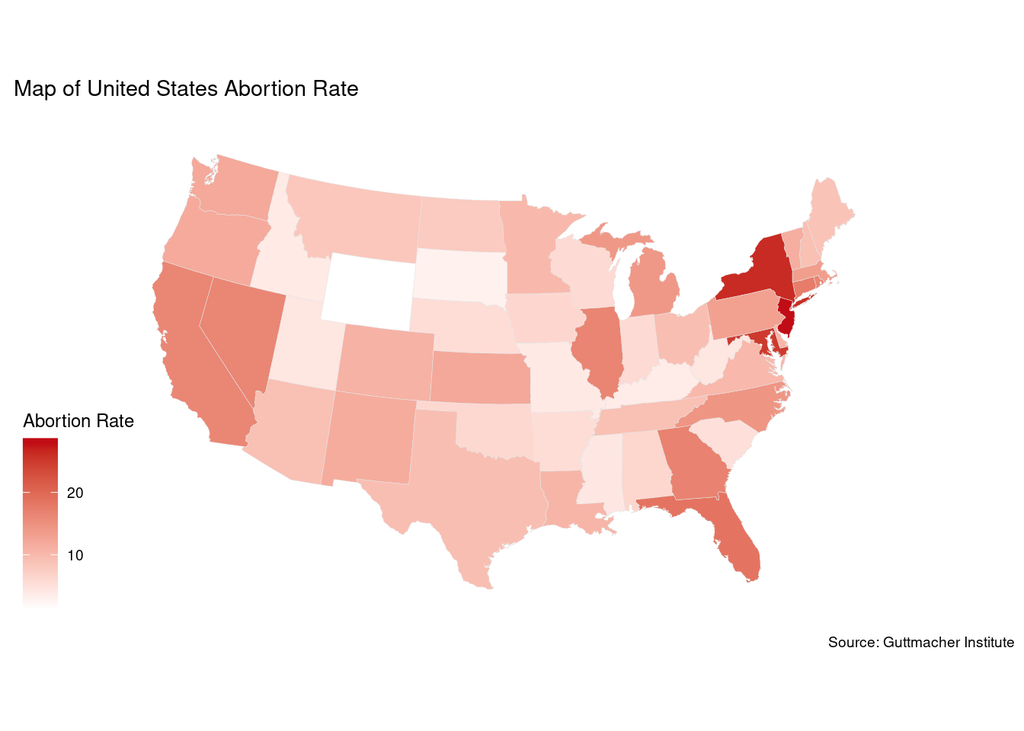

```r
p = ggplot(data=us_state_abort3,mapping=aes(x=long,y=lat,group=group, fill=Abortion_rate))
p + geom_polygon(color="gray90", size=0.1)+ scale_fill_gradient(low="white", high ="#C10C15")+
  coord_map(projection="albers",lat0=39,lat1=45) +theme_map() + labs(title="Map of United States Abortion Rate", fill="Abortion Rate", caption="Source: Guttmacher Institute")
```

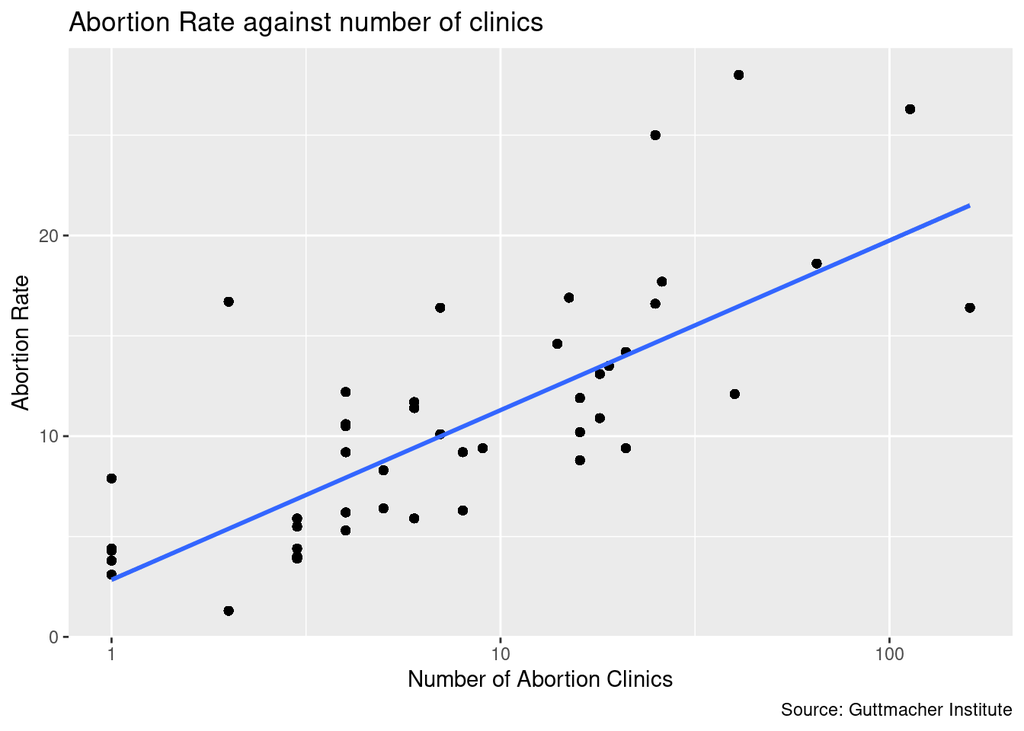

```r
x = ggplot(data=us_state_abort3,mapping=aes(x=No_of_abortion_clinics, y=Abortion_rate))
x + geom_point() +
  geom_smooth(method="lm") +
  scale_x_log10() +
  labs(x="Number of Abortion Clinics", y="Abortion Rate", title="Abortion Rate against number of clinics",
       caption="Source: Guttmacher Institute")
```

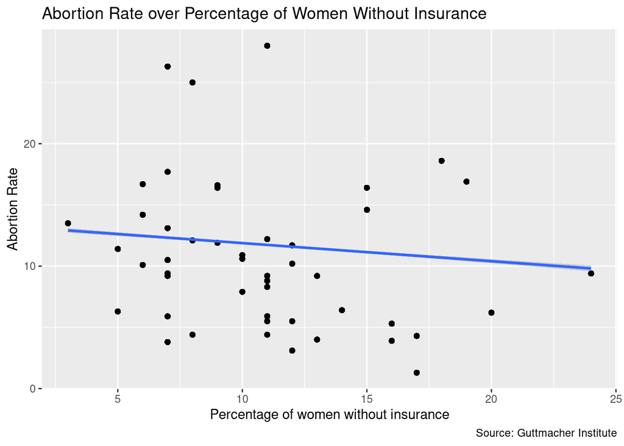

```r
z = ggplot(data=us_state_abort3,mapping=aes(x=Per_women_uninsur, y=Abortion_rate))
z + geom_point() +
  geom_smooth(method="lm") +
  labs(title="Abortion Rate over Percentage of Women Without Insurance",
       y="Abortion Rate", x="Percentage of women without insurance",
       caption="Source: Guttmacher Institute")
```

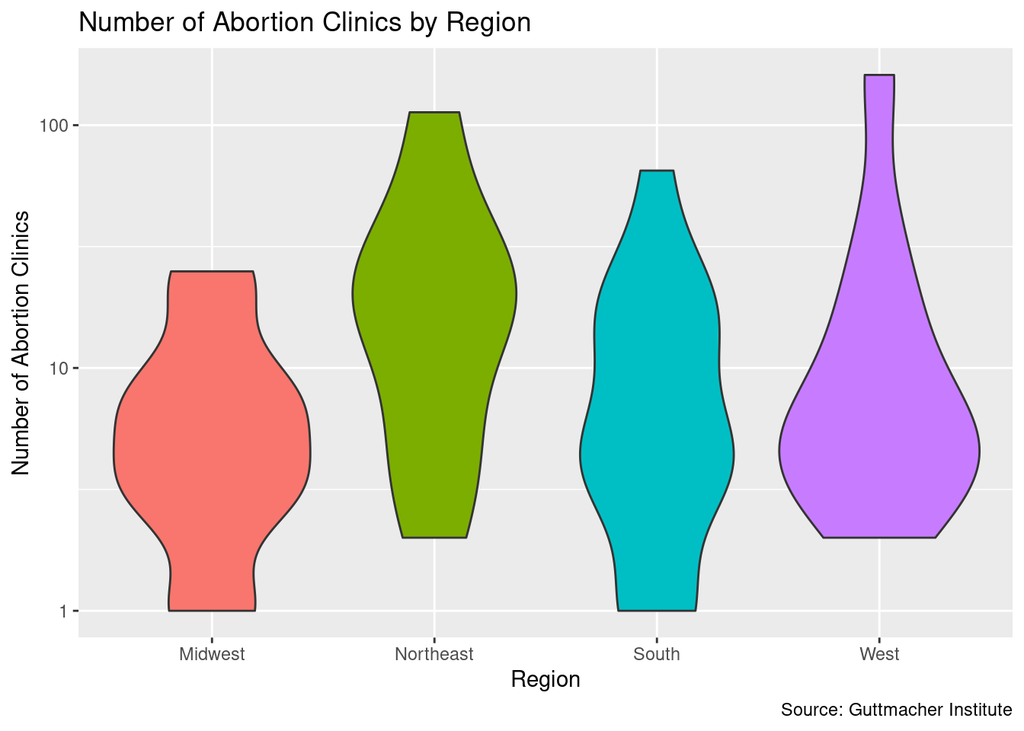

```r
w <- ggplot(us_state_abort4, aes(x=V1, y= No_of_abortion_clinics, fill=V1,  na.rm = TRUE))
w +  geom_violin( na.rm = TRUE) +
  scale_y_log10() +
  labs(title="Number of Abortion Clinics by Region", x="Region",
       y="Number of Abortion Clinics", caption = "Source: Guttmacher Institute")+
  theme(legend.position = "none")
```

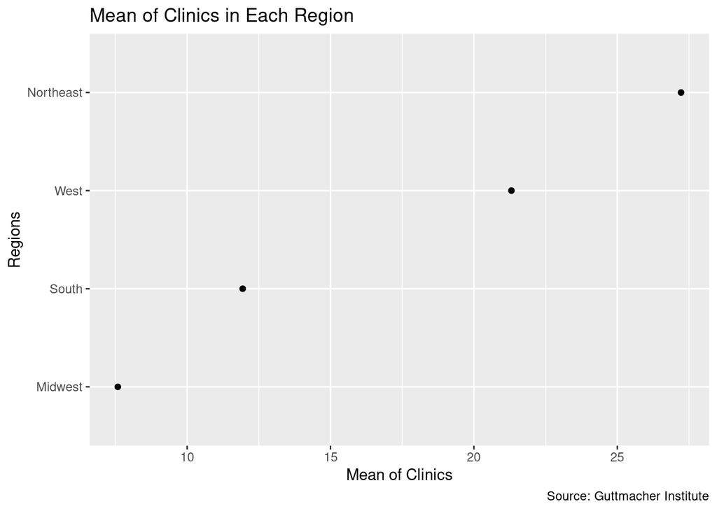

```r
newdata3 = us_state_abort4 %>%
  group_by(V1)  %>%
  summarize_if(is.numeric, list(mean=mean), na.rm = TRUE) %>%
ungroup()
o = ggplot(data=newdata3, aes(x=reorder(V1, No_of_abortion_clinics_mean), y=No_of_abortion_clinics_mean))
o + geom_point() +
  coord_flip() +
labs(title="Mean of Clinics in Each Region",x="Regions",y="Mean of Clinics",
     caption= "Source: Guttmacher Institute")
```